# Plotting

### Table of Contents

1. Table of Contents
2. Base Plot System
   - Base Histogram
   - Base Scatterplot
     - Scatterplot with Colors
     - Scatterplot with Regression Line
   - Base Boxplot
   - Multiple Base Plots
3. Plotting to Devices
4. ggplot2
   - qplot
   - ggplot

### Base Plot System

Basic plotting methods:

- `hist()`
- `plot()`
- `boxplot()`
- and multiple helpers, like `lines(), points(), text(), title(), mtext(), axis()`

Key plot parameters

- `pch` (i.e. plot char) pch values
- `lty` (i.e. line type)
- `lwd` (i.e. line width)
- `col` (i.e. color)
- `xlab` (i.e. x-axis label)
- `ylab` (i.e. y-axis label)

```r
# We will use the airquality data frame for our plotting purposes
library(datasets)
AQ = airquality # Short names for data frames are much nicer
str( AQ )
```

```
## 'data.frame':    153 obs. of  6 variables:
##  $ Ozone  : int  41 36 12 18 NA 28 23 19 8 NA ...
##  $ Solar.R: int  190 118 149 313 NA NA 299 99 19 194 ...
##  $ Wind   : num  7.4 8 12.6 11.5 14.3 14.9 8.6 13.8 20.1 8.6 ...
##  $ Temp   : int  67 72 74 62 56 66 65 59 61 69 ...
##  $ Month  : int  5 5 5 5 5 5 5 5 5 5 ...
##  $ Day    : int  1 2 3 4 5 6 7 8 9 10 ...
```

top

#### Base Histogram

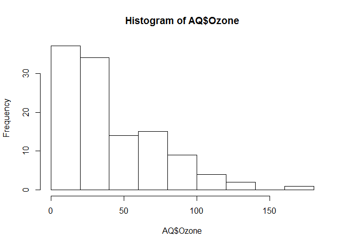

```r
# Draw a histogram
hist( AQ$Ozone )
```

top

#### Base Scatterplot

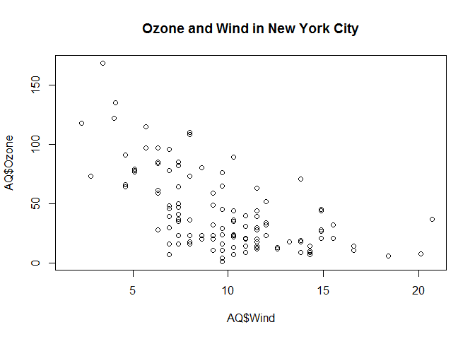

```r
# Draw a scatterplot
plot( AQ$Wind, AQ$Ozone )
title( main = "Ozone and Wind in New York City" )
```

top

#### Scatterplot with Colors

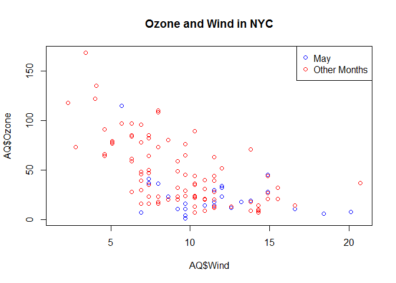

```r
# Create a logical vector to be used as a filter momentarily
is5 = ( AQ$Month == 5 )

# Draw a scatterplot again
#   note that type="n" sets up the plot, but does not draw points
plot( AQ$Wind, AQ$Ozone, main="Ozone and Wind in NYC", type="n" )
points( AQ[is5,]$Wind, AQ[is5,]$Ozone, col="blue" )
points( AQ[!is5,]$Wind, AQ[!is5,]$Ozone, col="red" )
legend("topright", pch=1, col=c("blue", "red"), legend=c("May", "Other Months"))
```

top

#### Scatterplot with Regression Line

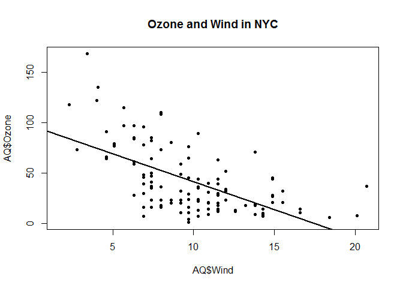

```r
# Draw a scatterplot with regression line
plot( AQ$Wind, AQ$Ozone, main="Ozone and Wind in NYC", pch=20 )
model = lm( Ozone ~ Wind, AQ )
abline( model, lwd=2 )
```

top

#### Base Boxplot

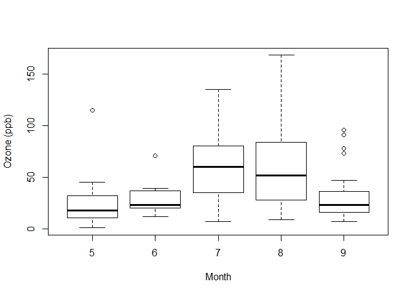

```r
# Draw a boxplot
AQ$Month = as.factor( AQ$Month )
boxplot( Ozone ~ Month, AQ, xlab="Month", ylab="Ozone (ppb)" )
```

top

#### Multiple Base Plots

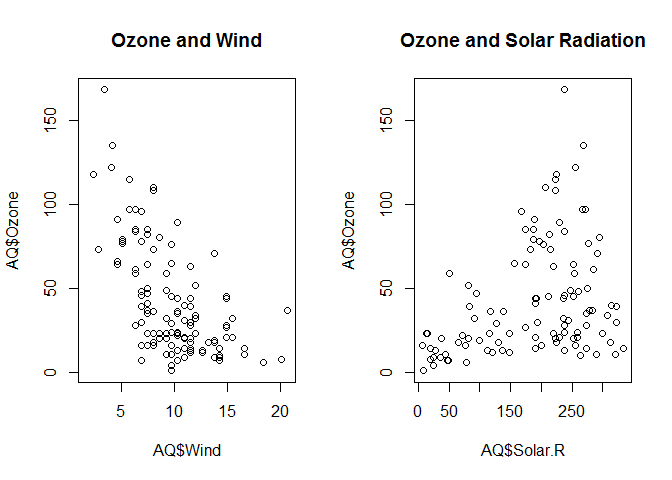

```r
# Draw multiple plots on single device
par( mfrow = c(1,2) )
plot( AQ$Wind, AQ$Ozone, main="Ozone and Wind" )
plot( AQ$Solar.R, AQ$Ozone, main="Ozone and Solar Radiation" )
```

```r
# Set parameter back to single plot
par( mfrow = c(1,1) )
```

top

### Plotting to Devices

It is possible to manage multiple devices for plotting

- To manage multiple devices, use dev.cur() and dev.set()
- To copy between devices, dev.copy() and dev.copy2pdf()

```r
# Draw to a file graphics device instead of default screen graphics device
pdf( file="example.pdf" )
x = rnorm(100)
hist(x)
print( dev.cur() )
```

```r
dev.off() #closes file device
```

The PDF is here.

top

### ggplot2

1. Two main functions:
   - `qplot()`
   - `ggplot()`
2. Main parameters:
   - data, generally a data.frame
   - aesthetic mappings
   - geoms (e.g. points, lines, shapes)
   - facets (i.e. condition)
   - stats (e.g. binning, quantiles, smoothing)
   - scales
   - coord systems
   - labels (e.g. `xlab(), ylab(), ggtitle()`_
   - themes
     - `theme()` for global tweaking
     - general themes e.g. `theme_gray(), theme_bw(),` … etc.
3. Build using layers:
   - plot data
   - overlay summary
   - metadata and annotation

```r
library(ggplot2) # comes with mpg data set
MPG = mpg     # make a copy to play with, using our preferred naming convention
str(MPG)
```

```
## Classes 'tbl_df', 'tbl' and 'data.frame':    234 obs. of  11 variables:
##  $ manufacturer: chr  "audi" "audi" "audi" "audi" ...
##  $ model       : chr  "a4" "a4" "a4" "a4" ...
##  $ displ       : num  1.8 1.8 2 2 2.8 2.8 3.1 1.8 1.8 2 ...
##  $ year        : int  1999 1999 2008 2008 1999 1999 2008 1999 1999 2008 ...
##  $ cyl         : int  4 4 4 4 6 6 6 4 4 4 ...
##  $ trans       : chr  "auto(l5)" "manual(m5)" "manual(m6)" "auto(av)" ...
##  $ drv         : chr  "f" "f" "f" "f" ...
##  $ cty         : int  18 21 20 21 16 18 18 18 16 20 ...
##  $ hwy         : int  29 29 31 30 26 26 27 26 25 28 ...
##  $ fl          : chr  "p" "p" "p" "p" ...
##  $ class       : chr  "compact" "compact" "compact" "compact" ...
```

top

#### qplot

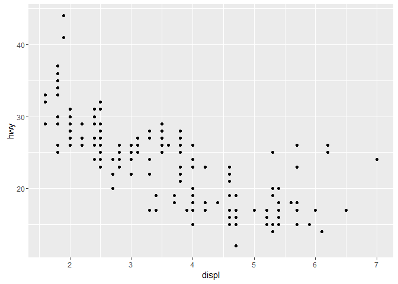

```r
# Scatterplot
p <- qplot(displ, hwy, data = MPG)
print(p)
```

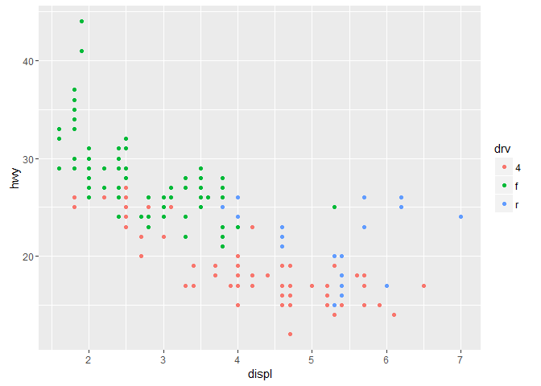

```r
# Scatterplot with color codes based on type of drive
p <- qplot(displ, hwy, data = MPG, color=drv)
print(p)
```

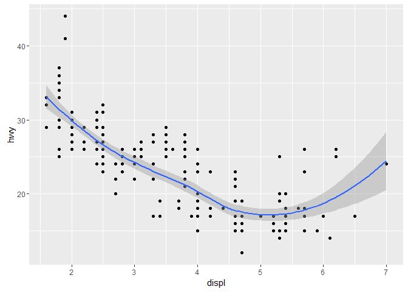

```r
# add a "smoother" for 95% confidence interval
p <- qplot(displ, hwy, data = MPG, geom = c("point", "smooth"))
print(p)
```

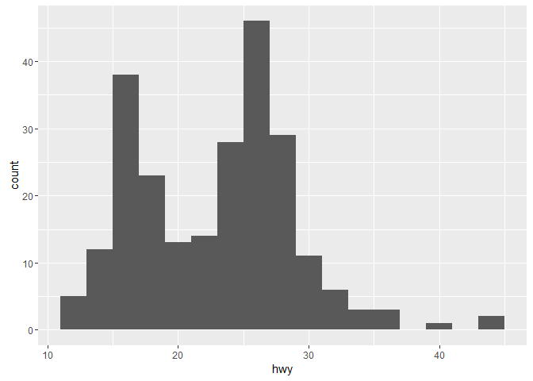

```r
# Histogram (inferred by single dimension provided)
#   For all of these histograms, specify a binwidth of bins to avoid warning
p <- qplot(hwy, data = MPG, binwidth=2)
print(p)
```

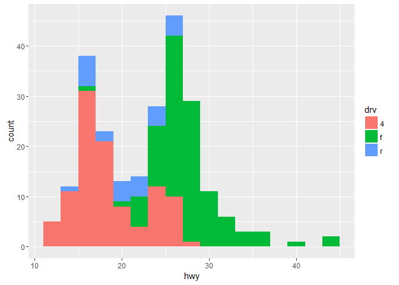

```r
# Histogram with color coding of subsets
p <- qplot(hwy, data = MPG, binwidth=2, fill=drv)
print(p)
```

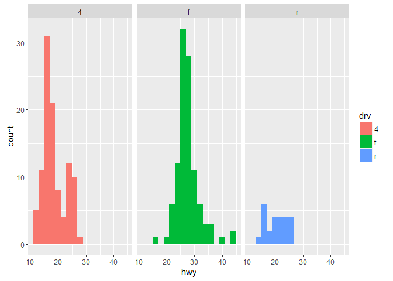

```r
# histogram with facets i.e. panels, in this case spanning HORIZONTALLY
p <- qplot(hwy, data = MPG, binwidth=2, fill=drv, facets = . ~ drv)
print(p)
```

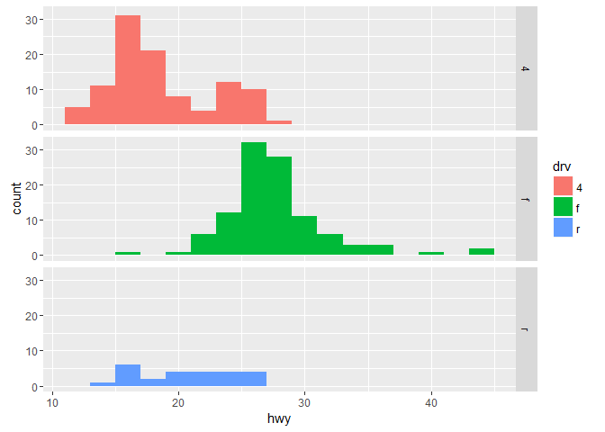

```r
# histogram with facets i.e. panels, in this case spanning VERTICALLY
p <- qplot(hwy, data = MPG, binwidth=2, fill=drv, facets = drv ~ .)
print(p)
```

top